# Exploratory Analysis for the Capstone Project

Rujuta Joshi

Saturday, March 26, 2016

## Project Objective and Milestone Objective

The main project is to create an application which can predict the most probable next words basis the user inputs. The prediction algorithm will use the data provided by SwiftKey to learn about the probable phrases, and predict the next words.

The objective of the milestone report, is to perform the primary steps of downloading, and staging the data, perform the exploratory analysis and describe the approach towards the main project.

## Structure of the Milestone Report :

1. A brief report on the exploratory analysis and the approach for the main project
2. Appendix which shows in brief the code used in case the reader is interested in more details.

## Exploratory Data Analysis Methodology

The Exploratory Data Analysis (EDA) methodology for this project will be to:

1. Load the text data into corpora.
2. Clean the corpora by removing extra white space, putting text all in lower-case, removing numbers, removing punctuation. In the final product, profanity will be removed.
3. Understand the size ,length of the data, frequency of the words, and most often used words.
4. Create n-gram tokens.
5. develop histograms to understand more commonly used words.

## Packages used for the analysis and brief look at the data

Following data analysis packages have been used.

1. Data.table : for Manipulation of data tables
2. tm, rJava, rWeka, NLP : for Natural language processing tasks
3. word cloud, ggplot2 : for visual representation of the data.

## A look at the data

Swiftkey has provided 3 sources of the data : twitter , Blog and newsdata. After loading the data, we find out the size of the data.

1. Load up all the required packages
2. Loading the data

```
##   Datasource  Length      Size
## 1   blogdata  899288 260564320
## 2   twitdata 2360148 316037344
## 3   newsdata   77259  20111392
```

## 3. Process the data by

a] Sample the data b] process the data :

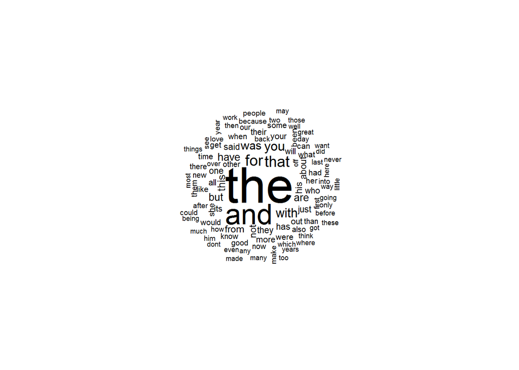

## Looking at the N-gram for the sample :

```
these graphs show the unigram, bigram and trigram in the histogram format. that can help us identify which are the more frequently used terms.
The bigrams are pairs of words, which appear together in the data, similarly trigrams are a group of 3 words, which appear together in the data.
Looking at those N Grams enables us to understand how the words appear together and that is a basis of the prediction model.
```

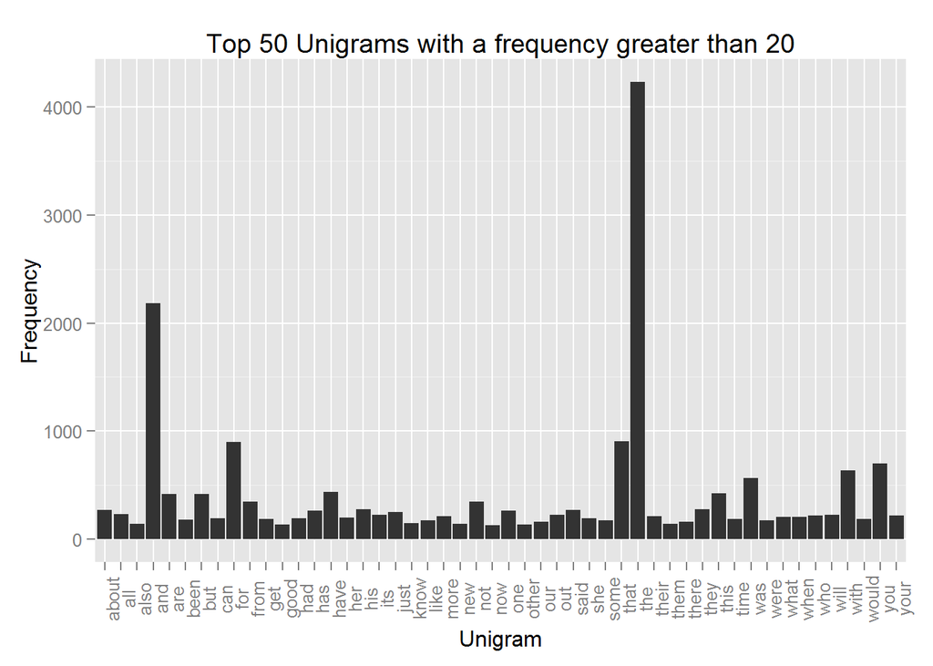

# Looking at a Bigram

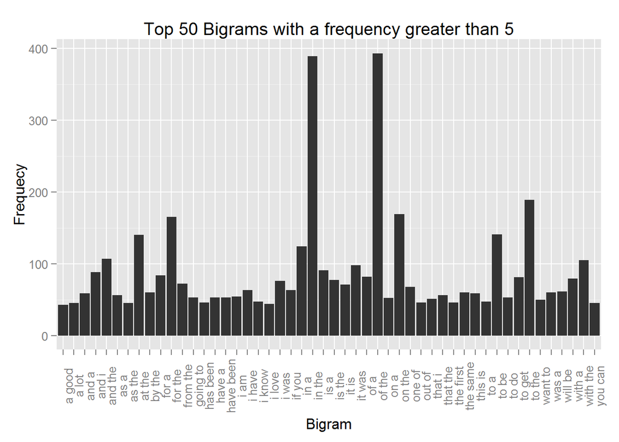

# Looking at a trigram

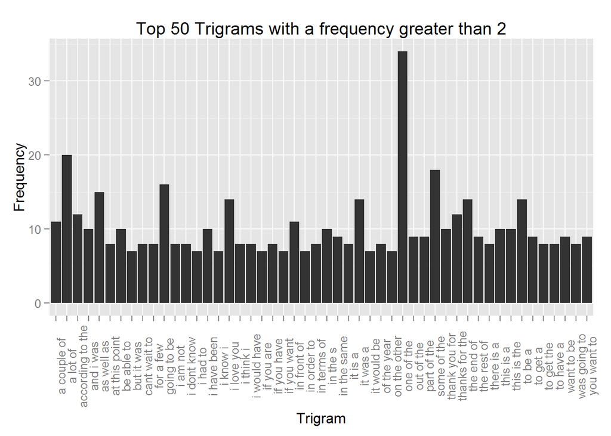

# The Approach for the main Project

The eventual aim is to derive a compact table of frequency count for all terms (single words and word pairs) small enough to be loaded into the Shiny server.

The system will use Markov prediction based on the probabilities of bigrams and trigrams in the combined data sets. Markov prediction determines what the next likely word based on shorter n-grams rather than whole sentences. This will perform better than attempting to assign probabilities to whole phrases, as the data sets cannot contain all possible sequences of words that could be entered by the user.

# APPENDIX

### 1. Loading up all the packages.

```r
library(tm)
library(wordcloud)
library(NLP)
library(openNLP)
library(rJava)
library(RWeka)
library(SnowballC)
library(data.table)
library(ggplot2)
```

### 2. Loading the data

```r
blogdata <- readLines("./en_US/en_US.blogs.txt")
twitdata <- readLines("./en_US/en_US.twitter.txt")
newsdata <- readLines("./en_US/en_US.news.txt")
totaldata <- list(blogdata, twitdata, newsdata)
length1 <- lapply(totaldata, length)
size1 <- lapply(totaldata, object.size)
size2 <- as.numeric(size1)
length2 <- as.numeric(length1)
sum <- data.frame(Datasource=c("blogdata", "twitdata","newsdata"), Length=length2, Size =size2)
print(sum)
```

```r
corpusdata <- Corpus(DirSource("en_US"))
set.seed(1234)
blogsample <- sample(corpusdata[[1]]$content, 1000)
newssample <- sample(corpusdata[[2]]$content, 1000)
twitsample <- sample(corpusdata[[3]]$content, 1000)
```

### 4. Processing the samples : cleaning, Removing numbers, removing punctuations, changing to lowercase letters.

```r
totalsampletobeprocessed <- paste(blogsample, newssample, twitsample)
totalsample <- Corpus(VectorSource(totalsampletobeprocessed))
totalsample <- tm_map(totalsample, removeNumbers)
totalsample <- tm_map(totalsample, removePunctuation)
totalsample <- tm_map(totalsample, content_transformer(tolower))
totalsample <- tm_map(totalsample, stripWhitespace)
totalsample <- tm_map(totalsample, PlainTextDocument)
wordcloud(totalsample, max.words=100, random.order=FALSE)
```

### Exploratory Analysis about Blog Sample Corpus, this calculates the frequency of the words, and finds out what are the top 10 owrds.

### Similar is done for the other 2 samples

```r
blogsamplecorpus <- Corpus(VectorSource(blogsample))
blogsamplecorpus <- tm_map(blogsamplecorpus, stripWhitespace)
blogsamplecorpus <- tm_map (blogsamplecorpus, content_transformer(tolower))
blogsamplecorpus <- tm_map(blogsamplecorpus, removePunctuation)
blogsamplecorpus <- tm_map(blogsamplecorpus, removeNumbers)
blogsamplecorpus <- tm_map(blogsamplecorpus, stemDocument)
blogsamplecorpus <- tm_map(blogsamplecorpus, PlainTextDocument)
dtm <- DocumentTermMatrix(blogsamplecorpus)
dtm <- as.matrix(dtm)
freq <- colSums(dtm)
ord <- order(freq)
topwordsinblog <- freq[tail(ord, n=10)]
print(topwordsinblog)
```

[output not shown]

### Looking at the N-gram for the sample.

We first tokenise the sample into unigrams, bigrams and trigrams this will help us understand the distribution of the words

```r
UnigramTokenizer <- function(x) NGramTokenizer(x, Weka_control(min = 1, max = 1))
en_us.sample.unigram <- TermDocumentMatrix(totalsample, control = list(tokenize = UnigramTokenizer))
FreqTerms <- findFreqTerms(en_us.sample.unigram, lowfreq = 20)
en_us.sample.frequency.vector.uni <- sort(rowSums(as.matrix(en_us.sample.unigram[FreqTerms,])),decreasing=TRUE)
en_us.sample.frequency.dataframe.uni <- data.frame(word = names(en_us.sample.frequency.vector.uni),freq=en_us.sample.frequency.vector.uni)

qplot(data=en_us.sample.frequency.dataframe.uni[1:50,], x=word, y=freq, geom="bar", stat="identity") + theme(axis.text.x=element_text(angle=90)) + labs(title="Top 50 Unigrams with a frequency greater than 20") + labs(x="Unigram") + labs(y="Frequency")


# Looking at a Bigram

BigramTokenizer <- function(x) NGramTokenizer(x, Weka_control(min = 2, max = 2))
en_us.sample.bigram <- TermDocumentMatrix(totalsample, control = list(tokenize = BigramTokenizer))
FreqTerms <- findFreqTerms(en_us.sample.bigram, lowfreq = 5)
en_us.sample.frequency.vector.bi <- sort(rowSums(as.matrix(en_us.sample.bigram[FreqTerms,])),decreasing=TRUE)
en_us.sample.frequency.dataframe.bi <- data.frame(word = names(en_us.sample.frequency.vector.bi),freq=en_us.sample.frequency.vector.bi)
qplot(data=en_us.sample.frequency.dataframe.bi[1:50,], x=word, y=freq, geom="bar", stat="identity") + theme(axis.text.x=element_text(angle=90)) + labs(title="Top 50 Bigrams with a frequency greater than 5") + labs(x="Bigram") + labs(y="Frequecy")



# Looking at a trigram


TrigramTokenizer <- function(x) NGramTokenizer(x, Weka_control(min = 3, max = 3))
en_us.sample.trigram <- TermDocumentMatrix(totalsample, control = list(tokenize = TrigramTokenizer))
FreqTerms <- findFreqTerms(en_us.sample.trigram, lowfreq = 2)
en_us.sample.frequency.vector.tri <- sort(rowSums(as.matrix(en_us.sample.trigram[FreqTerms,])),decreasing=TRUE)
en_us.sample.frequency.dataframe.tri <- data.frame(word = names(en_us.sample.frequency.vector.tri),freq=en_us.sample.frequency.vector.tri)

qplot(data=en_us.sample.frequency.dataframe.tri[1:50,], x=word, y=freq, geom="bar", stat="identity") + theme(axis.text.x=element_text(angle=90)) + labs(title="Top 50 Trigrams with a frequency greater than 2") + labs(x="Trigram") + labs(y="Frequency")
```